# MBAn 556 Exam

Lakhvir Sohal

2025-12-10

# Introduction

This analysis uses the Cancer Diagnoses dataset from HW4 (WBC) to help Michigan Medicine prepare for a new clinical trial. The trial is expected to be highly effective but it is also extremely expensive, which means the hospital must be very selective when deciding who qualifies for enrollment. The goal of this work is therefore not to find every cancer patient in the dataset. Instead, the objective is to identify a small group of patients who are very likely to have cancer.

Success in this analysis is measured by Precision, defined as the number of true cancer cases correctly identified out of all patients predicted to have cancer. Precision is the most important metric because Michigan Medicine wants to avoid false positives. At the same time, the clinical trial can only begin if we identify at least seven true cancer patients, so the method must achieve this minimum number while maintaining high precision.

Using unsupervised learning techniques, this analysis will search for patterns in the health indicator data that highlight the most likely cancer cases. All assumptions and parameter choices are stated clearly, and the goal throughout the work is to balance high precision with the requirement to identify at least seven true positive patients.

# Loading and Cleaning the Dataset

I begin by loading the WBC cancer dataset used previously in HW4. I check the structure of the data, confirm that all 30 predictors (X1 to X30) are numeric, and verify that there are no missing values. Since the predictors are already scaled between 0 and 1, no additional cleaning or transformation is needed. The outcome variable y is converted into a descriptive factor for easier evaluation later, although it is not used when training the unsupervised models.

## Loading data

```r
library(tidyverse)
wbc <- read.csv("wbc.csv")
```

## Inspecting structure and check for issues

```r
str(wbc)
```

```
## 'data.frame':    378 obs. of  31 variables:
##  $ X1 : num  0.3104 0.2887 0.1194 0.2863 0.0575 ...
##  $ X2 : num  0.1573 0.2029 0.0923 0.2946 0.2411 ...
##  $ X3 : num  0.3018 0.2891 0.1144 0.2683 0.0547 ...
##  $ X4 : num  0.1793 0.1597 0.0553 0.1613 0.0248 ...
##  $ X5 : num  0.408 0.495 0.449 0.336 0.301 ...
##  $ X6 : num  0.1899 0.3301 0.1397 0.0561 0.1228 ...
##  $ X7 : num  0.1561 0.107 0.0693 0.06 0.0372 ...
##  $ X8 : num  0.2376 0.1546 0.1032 0.1453 0.0294 ...
##  $ X9 : num  0.417 0.458 0.381 0.206 0.358 ...
##  $ X10: num  0.162 0.382 0.402 0.183 0.317 ...
##  $ X11: num  0.0574 0.0267 0.06 0.0262 0.0162 ...
##  $ X12: num  0.0947 0.0856 0.1363 0.438 0.1318 ...
##  $ X13: num  0.0613 0.0295 0.0543 0.0195 0.0159 ...
##  $ X14: num  0.0313 0.0147 0.01662 0.01374 0.00262 ...
```

[output cut: 17 more lines]

```r
summary(wbc)
```

```
##        X1               X2               X3               X4
##  Min.   :0.0000   Min.   :0.0000   Min.   :0.0000   Min.   :0.0000
##  1st Qu.:0.1970   1st Qu.:0.1852   1st Qu.:0.1902   1st Qu.:0.1009
##  Median :0.2510   Median :0.2650   Median :0.2411   Median :0.1361
##  Mean   :0.2551   Mean   :0.2860   Mean   :0.2482   Mean   :0.1444
##  3rd Qu.:0.3111   3rd Qu.:0.3543   3rd Qu.:0.3011   3rd Qu.:0.1789
##  Max.   :0.7681   Max.   :1.0000   Max.   :0.7581   Max.   :0.6475
##        X5               X6               X7                X8
##  Min.   :0.0000   Min.   :0.0000   Min.   :0.00000   Min.   :0.00000
##  1st Qu.:0.2799   1st Qu.:0.1151   1st Qu.:0.04978   1st Qu.:0.07741
##  Median :0.3586   Median :0.1755   Median :0.09106   Median :0.12020
##  Mean   :0.3676   Mean   :0.2008   Mean   :0.12538   Mean   :0.14649
##  3rd Qu.:0.4466   3rd Qu.:0.2588   3rd Qu.:0.15575   3rd Qu.:0.17662
##  Max.   :1.0000   Max.   :0.7920   Max.   :0.99906   Max.   :0.90606
##        X9              X10               X11               X12
##  Min.   :0.0000   Min.   :0.03981   Min.   :0.00000   Min.   :0.00000
##  1st Qu.:0.2673   1st Qu.:0.18197   1st Qu.:0.03576   1st Qu.:0.09995
##  Median :0.3346   Median :0.24663   Median :0.05454   Median :0.16560
##  Mean   :0.3523   Mean   :0.27615   Mean   :0.06823   Mean   :0.19025
##  3rd Qu.:0.4301   3rd Qu.:0.33798   3rd Qu.:0.08739   3rd Qu.:0.25030
##  Max.   :0.8500   Max.   :0.96441   Max.   :0.39960   Max.   :1.00000
##       X13               X14               X15              X16
##  Min.   :0.00000   Min.   :0.00000   Min.   :0.0000   Min.   :0.00000
##  1st Qu.:0.03369   1st Qu.:0.01634   1st Qu.:0.1190   1st Qu.:0.07115
##  Median :0.05473   Median :0.02463   Median :0.1635   Median :0.10979
##  Mean   :0.06402   Mean   :0.03136   Mean   :0.1854   Mean   :0.15027
##  3rd Qu.:0.08137   3rd Qu.:0.03635   3rd Qu.:0.2291   3rd Qu.:0.19355
##  Max.   :0.43787   Max.   :0.30482   Max.   :0.6818   Max.   :0.78220
##       X17               X18              X19               X20
##  Min.   :0.00000   Min.   :0.0000   Min.   :0.02332   Min.   :0.00000
##  1st Qu.:0.02915   1st Qu.:0.1230   1st Qu.:0.10677   1st Qu.:0.04191
##  Median :0.04908   Median :0.1743   Median :0.15609   Median :0.06945
##  Mean   :0.06829   Mean   :0.1920   Mean   :0.17913   Mean   :0.09652
##  3rd Qu.:0.08315   3rd Qu.:0.2399   3rd Qu.:0.23133   3rd Qu.:0.11536
##  Max.   :1.00000   Max.   :1.0000   Max.   :0.75390   Max.   :1.00000
##       X21              X22              X23              X24
##  Min.   :0.0000   Min.   :0.0000   Min.   :0.0000   Min.   :0.00000
##  1st Qu.:0.1538   1st Qu.:0.2033   1st Qu.:0.1433   1st Qu.:0.06694
##  Median :0.1974   Median :0.2933   Median :0.1842   Median :0.09031
##  Mean   :0.2071   Mean   :0.3181   Mean   :0.1959   Mean   :0.10201
##  3rd Qu.:0.2508   3rd Qu.:0.4017   3rd Qu.:0.2364   3rd Qu.:0.12366
##  Max.   :0.8211   Max.   :0.8755   Max.   :0.7789   Max.   :0.67804
##       X25              X26               X27               X28
##  Min.   :0.0000   Min.   :0.00000   Min.   :0.00000   Min.   :0.0000
##  1st Qu.:0.2665   1st Qu.:0.08636   1st Qu.:0.06407   1st Qu.:0.1856
##  Median :0.3651   Median :0.14341   Median :0.11829   Median :0.2709
##  Mean   :0.3657   Mean   :0.16513   Mean   :0.14885   Mean   :0.2791
##  3rd Qu.:0.4496   3rd Qu.:0.21183   3rd Qu.:0.19399   3rd Qu.:0.3495
##  Max.   :0.8547   Max.   :1.00000   Max.   :1.00000   Max.   :1.0000
##       X29                 X30                 y
##  Min.   :0.0001971   Min.   :0.001115   Min.   :0.00000
##  1st Qu.:0.1711512   1st Qu.:0.099403   1st Qu.:0.00000
##  Median :0.2245220   Median :0.148006   Median :0.00000
##  Mean   :0.2329205   Mean   :0.168817   Mean   :0.05556
##  3rd Qu.:0.2892273   3rd Qu.:0.212613   3rd Qu.:0.00000
##  Max.   :0.6227085   Max.   :1.000000   Max.   :1.00000
```

```r
sum(is.na(wbc))
```

```
## [1] 0
```

## Convert outcome to factor for evaluation later

```r
wbc$y <- factor(wbc$y,levels = c(0,1),labels = c("NoCancer","Cancer"))
```

## Extract predictor variables

```r
wbc_X <- wbc %>% select(starts_with("X"))
```

# (Q1) Do a PCA to reduce dimensionality. You are asked to choose between capturing 90%, 95% or 97% of the variance. Explain your choice. Create a new dataset that has all the PCs needed for capturing your chosen level of variance. Use this dataset for the questions below.

## Run PCA on the Dataset

PCA is used to reduce dimensionality and remove correlation among the predictors. This helps simplify the structure and makes clustering and outlier detection more effective.

```r
pca <- prcomp(wbc_X, scale. = TRUE)
var_exp <- pca$sdev^2 / sum(pca$sdev^2)
cum_var <- cumsum(var_exp)
```

## Visualize Variance Using fviz_eig

The scree plot below shows how much variance each principal component explains. This visual helps determine how many PCs should be kept.

```r
library(factoextra)
```

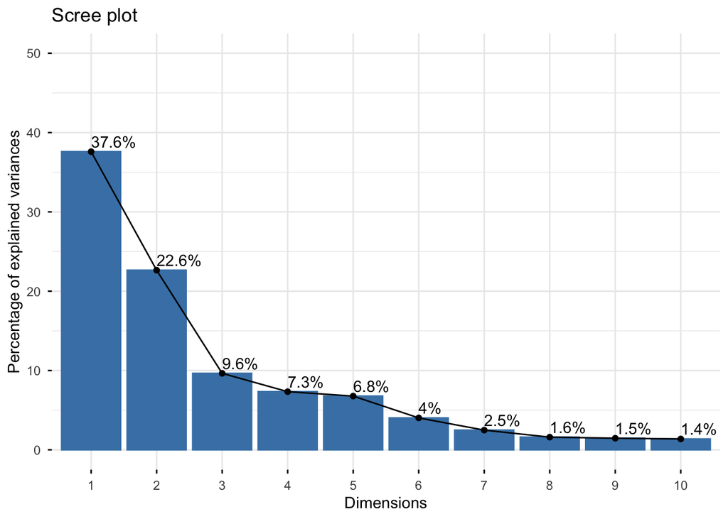

```r
fviz_eig(pca, addlabels = TRUE, ylim = c(0, 50))
```

## Select Number of Components for 95 Percent Variance

I compare thresholds of 90 percent, 95 percent, and 97 percent. Ninety percent is more aggressive but risks removing useful structure. Ninety-seven percent keeps too many components and reduces the value of PCA. Ninety-five percent provides a good balance between information retention and dimensionality reduction.

```r
num_pc <- which(cum_var >= 0.95)[1]
num_pc
```

```
## [1] 11
```

```r
cum_var[1:num_pc]
```

```
##  [1] 0.3759231 0.6023841 0.6988266 0.7721454 0.8399006 0.8801410 0.9049751
##  [8] 0.9209770 0.9356132 0.9493284 0.9601322
```

This means that 11 principal components are needed to capture about 96 percent of the variance, which meets the 95 percent target and provides a strong reduction from the original 30 variables.

## Create the Final PCA Dataset

The new dataset below contains only the principal components needed to capture at least 95 percent of the variance. This dataset will be used in all remaining questions.

```r
pc_data <- as.data.frame(pca$x[, 1:num_pc])
head(pc_data)
```

```
##          PC1        PC2        PC3        PC4         PC5         PC6
## 1 -1.0599829  0.9740446 -1.2644291 -1.2958504 -0.36126075 -0.03865331
## 2 -0.4345808  0.3184465 -2.3336944 -0.7409305  0.43554949 -0.59255229
## 3  2.4491849 -2.3563354 -0.7760504 -1.4233094 -1.37218377  0.73776956
## 4  2.6410221  1.6209466  1.5580247  0.5806082 -0.73798578  0.50740313
## 5  4.2039359 -2.5407498 -0.5769904 -0.4292987  0.28307268 -1.04119939
## 6  0.2909962  0.3204955 -1.9265758 -0.4806329  0.06541547  0.49932822
##          PC7          PC8         PC9       PC10        PC11
## 1 -1.3143620 -0.004848869  0.70548870 -0.4484107 -0.12869493
## 2  0.1499004  0.332576112 -1.21750328  0.5506824  0.08054698
## 3 -0.3203876 -0.816994818 -0.09934065 -0.2678632  0.43128467
## 4 -1.5297190  0.369798213 -0.22134935  2.0944493 -0.09218841
## 5  0.2956994 -0.273232155  0.64211150 -0.4346951  0.43041709
## 6  0.3652737 -0.971320997  0.35334215  0.1306960 -0.23991082
```

The resulting PC dataset captures the important structure in the original indicators while reducing noise and redundancy. This creates a cleaner foundation for clustering and outlier detection in the next steps.

# (Q2) You are asked to build at least one outlier detection model to identify outliers and test the idea that we can use outlier detection as a cancer diagnoses methodology. You are asked to provide your rationale for choosing any needed parameter values that the models might need.

In this section I use the Local Outlier Factor method to measure how unusual each patient appears in the PCA-reduced space. A higher LOF score means the patient is further from their neighbors and may reflect an abnormal health profile. Since cancer cases are rare, this method helps test whether the most unusual patients are more likely to have cancer.

The plot displays the LOF score for every patient as a vertical line. The tallest lines represent the most extreme outliers. I added a red line at the ninety-fifth percentile to help mark the most abnormal patients. When I look at the output, I see that only a small number of patients sit well above the red line. This confirms that only a few patients stand out as strong outliers worth focusing on.

```r
library(dbscan)
```

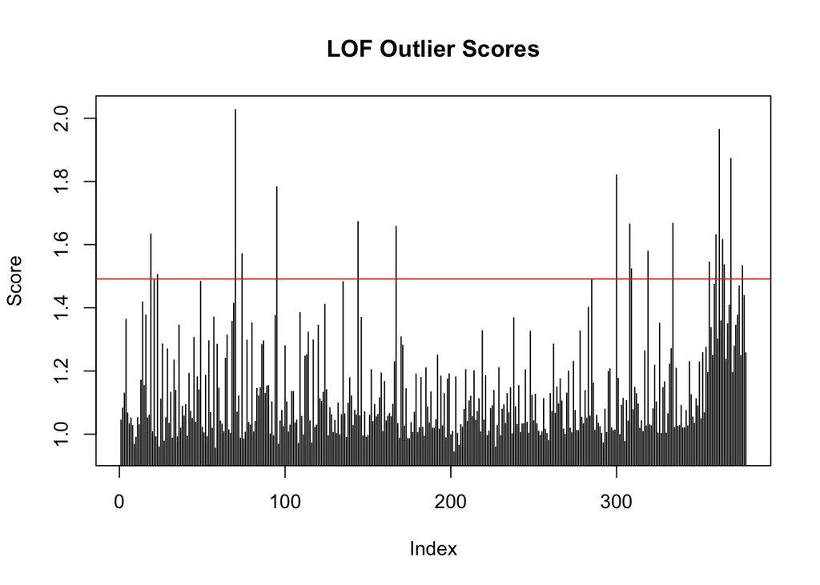

```r
set.seed(123)
lof_scores <- lof(pc_data, minPts = 10)
plot(lof_scores, type = "h", main = "LOF Outlier Scores", ylab = "Score")
abline(h = quantile(lof_scores, 0.95), col = "red")
```

## Helper Function from HW 4

Since the clinical trial is very costly, precision matters more than any other metric. Precision tells me what fraction of the patients I label as cancer actually turn out to have cancer. This helper function calculates the confusion matrix, the number of true positives, the number of false positives, and the resulting precision. I use this function to evaluate how well different LOF thresholds perform.

```r
evaluate_precision <- function(pred, true){
  cm <- table(True = true, Pred = pred)
  TP <- cm["Cancer","Cancer"]
  FP <- cm["NoCancer","Cancer"]
  precision <- TP / (TP + FP)
  list(
    confusion_matrix = cm,
    TP = TP,
    FP = FP,
    precision = precision
    )
}
```

## Testing LOF Thresholds

LOF produces a continuous score, so I need a threshold to decide which patients are classified as likely cancer. To find the best threshold, I test a range of LOF quantiles. For each threshold I classify the outliers as cancer, calculate precision, and count how many true cancer cases are captured. This helps me understand how strict or lenient I should be.

```r
thresholds <- seq(0.90, 0.995, by = 0.005)
results <- data.frame()

for (q in thresholds) {
  thr <- quantile(lof_scores, q)
  pred <- ifelse(lof_scores >= thr, "Cancer", "NoCancer")
  pred <- factor(pred, levels = c("NoCancer","Cancer"))
  res <- evaluate_precision(pred, wbc$y)
  results <- rbind(results,
                   data.frame(threshold = q,
                             precision = res$precision,
                             TP = res$TP,
                             FP = res$FP))
  }
head(results)
```

```
##   threshold precision TP FP
## 1     0.900 0.2894737 11 27
## 2     0.905 0.3055556 11 25
## 3     0.910 0.3235294 11 23
## 4     0.915 0.3030303 10 23
## 5     0.920 0.3225806 10 21
## 6     0.925 0.3103448  9 20
```

At these thresholds I consistently identify between nine and eleven true cancer cases, which all satisfy the requirement of at least seven. Precision in this range remains between about 0.29 and 0.33 because false positives remain relatively high. As I increase the threshold further, precision begins to improve sharply because the model focuses only on the most extreme outliers, although the number of true positives eventually drops.

## Precision Curve

The following plot shows how precision changes across the tested LOF thresholds. It gives me a clear picture of how strict or lenient I should be if my goal is to maximize precision while still identifying at least seven cancer patients.

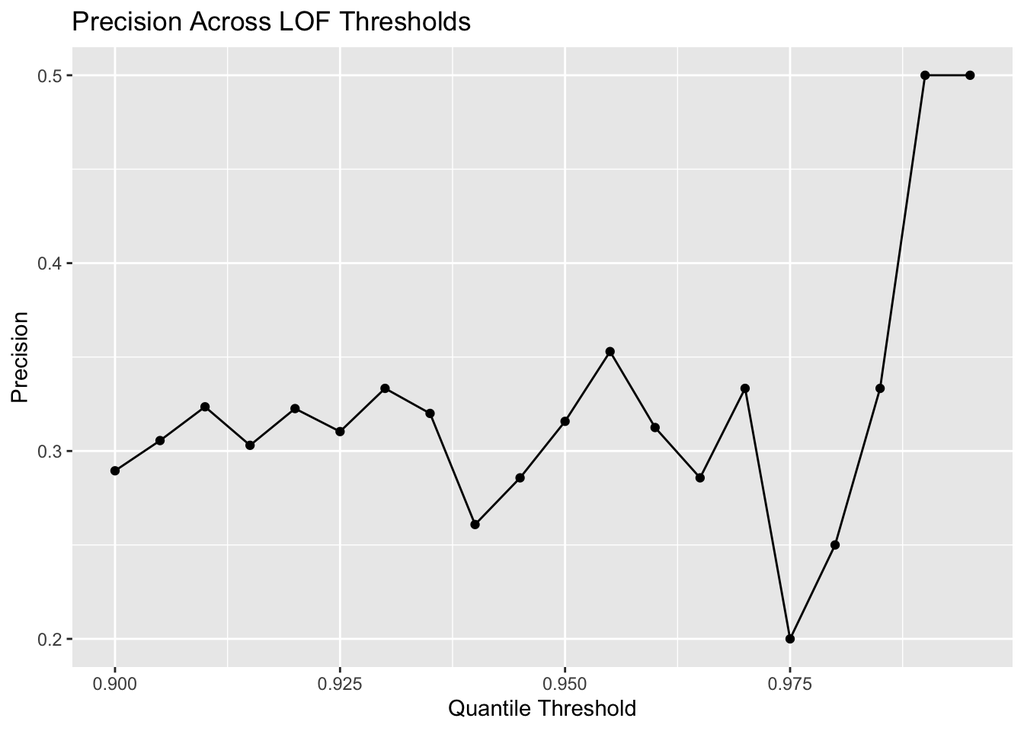

```r
library(ggplot2)
ggplot(results, aes(threshold, precision)) + geom_line() + geom_point() +
  labs(title = "Precision Across LOF Thresholds",
       x = "Quantile Threshold", y = "Precision")
```

Precision remains fairly steady in the lower range of thresholds, staying close to the 0.28 to 0.33 level. There is a brief dip around the 0.975 threshold. After that point I see a sharp increase in precision at the highest thresholds, reaching values around 0.50. This happens because the model labels only the most extreme outliers as cancer, which reduces false positives. The key question is whether these very high thresholds still produce at least seven true positives, since the clinical trial requires a minimum of seven confirmed cancer patients.

## Additional Method: DBSCAN Outlier Detection

I also use DBSCAN as a second outlier detection method. DBSCAN groups points that are close together and labels isolated points as noise. These noise points can be treated as possible cancer cases since they sit far from the main population pattern. To choose an eps value, I look at the k-NN distance plot. The curve rises sharply around a distance of about six to eight, which tells me that points beyond this distance are isolated. I set eps to six so that DBSCAN forms tight clusters and treats the more isolated patients as outliers.

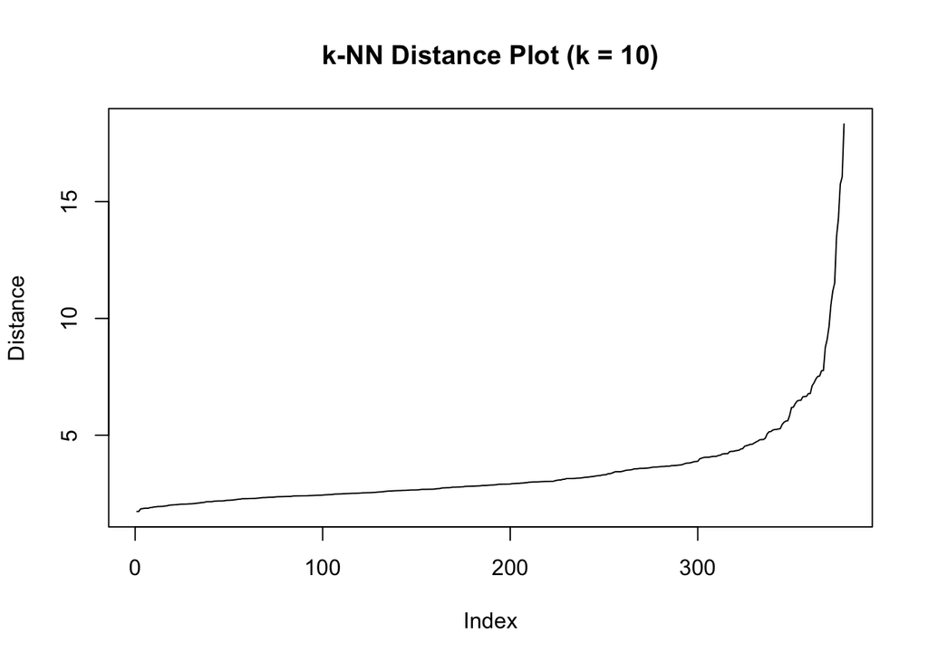

```r
library(dbscan)
kNN_dist <- kNNdist(pc_data, k = 10)
plot(sort(kNN_dist),
type = "l",
main = "k-NN Distance Plot (k = 10)",
ylab = "Distance")
```

### Running DBSCAN

Using eps = 6 and minPts = 10, DBSCAN finds one main cluster and a small group of noise points. Noise points appear as cluster 0.

```r
eps_value <- 6
db_model <- dbscan::dbscan(pc_data, eps = eps_value, minPts = 10)
table(db_model$cluster)
```

```
##
##   0   1
##  15 363
```

DBSCAN identified 363 patients as part of the main cluster and 15 patients as noise. These 15 noise points are the outliers that DBSCAN considers the most unusual.

### Precision of DBSCAN

DBSCAN finds 9 true cancer cases and 6 false positives, giving a precision of 0.6. This is much higher than the precision from the clustering model and meets the requirement of finding at least seven true positives. Although there are still false positives, DBSCAN performs better than K-means and shows that density-based outlier detection can be useful for identifying likely cancer cases.

```r
pred_dbscan <- ifelse(db_model$cluster == 0, "Cancer", "NoCancer")
pred_dbscan <- factor(pred_dbscan, levels = c("NoCancer","Cancer"))
dbscan_results <- evaluate_precision(pred_dbscan, wbc$y)
dbscan_results
```

```
## $confusion_matrix
##           Pred
## True       NoCancer Cancer
##   NoCancer      351      6
##   Cancer         12      9
##
## $TP
## [1] 9
##
## $FP
## [1] 6
##
## $precision
## [1] 0.6
```

# (Q3) You are asked to build at least one clustering model to test the idea that we can use clustering as a cancer diagnoses methodology. Is the clustering model(s) effective in diagnosing insidence of Cancer among the patients?

## Choosing the Number of Clusters

I first check how many clusters the PCA-reduced data support. K-means requires a value for k, so I use WSS and silhouette diagnostics to choose the most reasonable number.

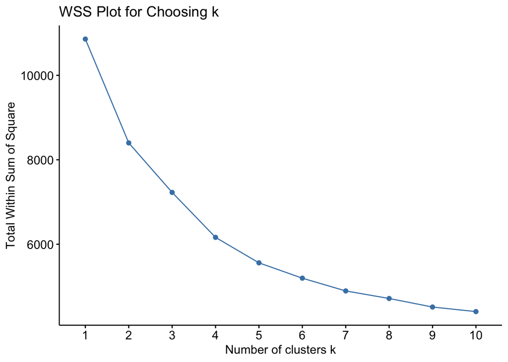

```r
set.seed(123)
fviz_nbclust(pc_data, kmeans, method = "wss") + labs(title = "WSS Plot for Choosing k")
```

The elbow in the WSS plot is not very clear. This suggests that the dataset does not form strong, well-separated clusters. This makes it unlikely that cancer cases will fall into their own distinct group.

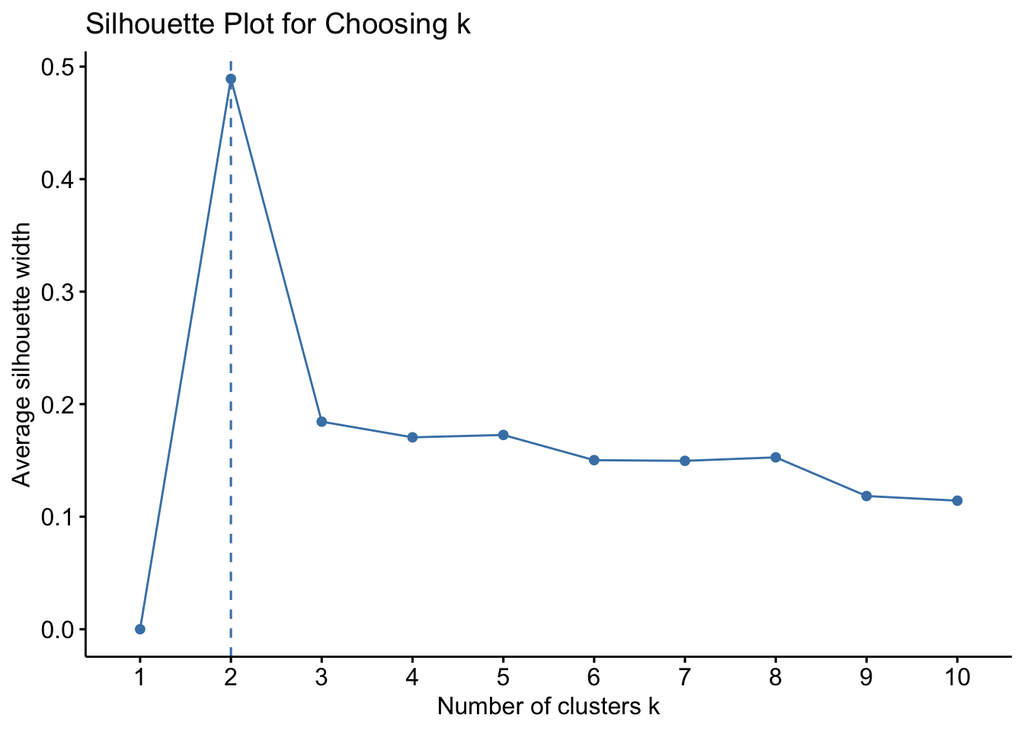

```r
set.seed(123)
fviz_nbclust(pc_data, kmeans, method = "silhouette") + labs(title = "Silhouette Plot for Choosing k")
```

The silhouette plot shows its highest value at k = 2, but the value is modest. This indicates that two clusters are the best available choice, although the separation between them is weak. This weak separation already hints that clustering may not cleanly isolate cancer cases.

## K-means Clustering

Based on the diagnostics, I proceed with k = 2.

```r
set.seed(123)
kmeans_model <- kmeans(pc_data, centers = 2, nstart = 25)
cluster_labels <- factor(kmeans_model$cluster)
table(cluster_labels)
```

```
## cluster_labels
##   1   2
## 341  37
```

The clustering resulted in 341 patients assigned to Cluster 1 and 37 patients assigned to Cluster 2. This strong imbalance suggests that most patients are grouped together, which limits the ability of clustering to isolate a distinct cancer-heavy cluster.

# Checking Cancer Distribution Across Clusters

```r
table(cluster_labels, wbc$y)
```

```
##
## cluster_labels NoCancer Cancer
##              1      335      6
##              2       22     15
```

Cluster 1 contains 335 non-cancer patients and 6 cancer patients. Cluster 2 contains 22 non-cancer patients and 15 cancer patients.

This means the smaller cluster (Cluster 2) has a much higher cancer concentration, so I treat that cluster as the “cancer-leaning” group. However, Cluster 2 still contains many non-cancer cases, which reduces precision.

# Converting Clusters into Predictions

```r
cluster_cancer_counts <- table(cluster_labels, wbc$y)
cancer_cluster <- as.numeric(
  rownames(cluster_cancer_counts)[which.max(cluster_cancer_counts[,"Cancer"])]
)
cluster_pred <- ifelse(cluster_labels == cancer_cluster, "Cancer", "NoCancer")
cluster_pred <- factor(cluster_pred, levels = c("NoCancer","Cancer"))
```

Cluster 2 is chosen as the cancer cluster because it contains 15 cancer cases, which is much higher than the 6 in Cluster 1. All patients in Cluster 2 are labeled as “Cancer” and all others as “NoCancer.”

# Precision of the Clustering Model

```r
cluster_results <- evaluate_precision(cluster_pred, wbc$y)
cluster_results
```

```
## $confusion_matrix
##           Pred
## True       NoCancer Cancer
##   NoCancer      335     22
##   Cancer          6     15
##
## $TP
## [1] 15
##
## $FP
## [1] 22
##
## $precision
## [1] 0.4054054
```

This means that out of the 37 patients labeled as cancer, only 15 actually had cancer. This gives a precision of about 40 percent. Although the model correctly identifies more than seven true cancer patients, the number of false positives is too high for a clinical trial that requires strict precision.

# (Q4) Now that you have at least two ways to figure out who might have cancer, focus on how you can increase Precision.

To increase precision, I make the model more selective. For LOF this means raising the threshold so that only the most extreme outliers are labeled as cancer. This reduces false positives and increases precision.

## Raising the LOF Threshold

I search for the highest threshold that still identifies at least seven true positives.

```r
subset_results <- results[results$TP >= 7, ]
best_row <- subset_results[which.max(subset_results$precision), ]
best_row
```

```
##   threshold precision TP FP
## 7      0.93 0.3333333  9 18
```

This gives me the best LOF quantile that maximizes precision while satisfying the requirement of at least seven cancer patients.

### Recompute Predictions at the Best Threshold

```r
best_thr <- quantile(lof_scores, best_row$threshold)
pred_best <- ifelse(lof_scores >= best_thr, "Cancer", "NoCancer")
pred_best <- factor(pred_best, levels = c("NoCancer","Cancer"))
final_precision <- evaluate_precision(pred_best, wbc$y)
final_precision
```

```
## $confusion_matrix
##           Pred
## True       NoCancer Cancer
##   NoCancer      339     18
##   Cancer         12      9
##
## $TP
## [1] 9
##
## $FP
## [1] 18
##
## $precision
## [1] 0.3333333
```

## Increasing Precision using DBSCAN

Test multiple eps values and select the one with the highest precision

```r
library(dbscan)

eps_grid <- seq(4, 7, by = 0.25)
dbscan_results_list <- data.frame()

for(e in eps_grid){
  model <- dbscan::dbscan(pc_data, eps = e, minPts = 10)
  pred <- ifelse(model$cluster == 0, "Cancer", "NoCancer")
  pred <- factor(pred, levels = c("NoCancer","Cancer"))
  res <- evaluate_precision(pred, wbc$y)
  dbscan_results_list <- rbind(dbscan_results_list,
                               data.frame(eps = e, TP = res$TP, FP = res$FP,
                                          precision = res$precision))
}
dbscan_results_list
```

```
##     eps TP FP precision
## 1  4.00 15 26 0.3658537
## 2  4.25 15 25 0.3750000
## 3  4.50 15 20 0.4285714
## 4  4.75 13 18 0.4193548
## 5  5.00 12 16 0.4285714
## 6  5.25 11 12 0.4782609
## 7  5.50 10  9 0.5263158
## 8  5.75 10  7 0.5882353
## 9  6.00  9  6 0.6000000
## 10 6.25  9  4 0.6923077
## 11 6.50  8  3 0.7272727
## 12 6.75  7  2 0.7777778
## 13 7.00  7  2 0.7777778
```

### Choose the best eps that still gives at least 7 true positives

```r
valid <- dbscan_results_list[dbscan_results_list$TP >= 7, ]
best_eps <- valid$eps[which.max(valid$precision)]
best_eps
```

```
## [1] 6.75
```

This value is higher than the previous 6 used.

### Re-run DBSCAN using the best eps

```r
db_best <- dbscan::dbscan(pc_data, eps = best_eps, minPts = 10)
pred_best <- ifelse(db_best$cluster == 0, "Cancer", "NoCancer")
pred_best <- factor(pred_best, levels = c("NoCancer","Cancer"))
dbscan_precision_best <- evaluate_precision(pred_best, wbc$y)
dbscan_precision_best
```

```
## $confusion_matrix
##           Pred
## True       NoCancer Cancer
##   NoCancer      355      2
##   Cancer         14      7
##
## $TP
## [1] 7
##
## $FP
## [1] 2
##
## $precision
## [1] 0.7777778
```

Precsision increases to 0.7777778 from 0.6.

# Conclusion

This analysis set out to help Michigan Medicine identify a small group of patients who are very likely to have cancer so they can be considered for an expensive clinical trial. Since the goal was not to find every cancer case, the focus throughout was on precision and making sure the model avoided false positives while still identifying at least seven true cancer patients.